# Homework_2

Emily Ogden

January 15, 2020

# Scenario 1

1. $H_0:\mu_{2009}=\mu_{2010}$  
   $H_A:\mu_{2009}\neq\mu_{2010}$

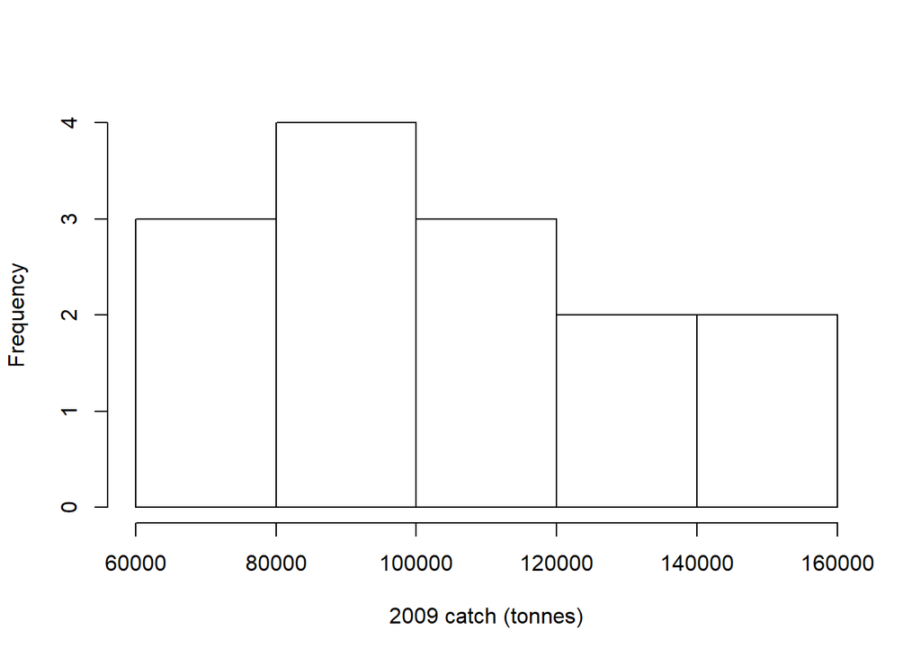

```r
catch1=c(91900,95200,61900,73600,114300,117000,129500,74200,112700,152100,90700,89400,127500,142200)
catch2=c(82900,86700,46900,41300,91600,100400,128400,55900,101700,139100,79300,76100,114100,139800)
hist(catch1,main="",xlab="2009 catch (tonnes)")
```

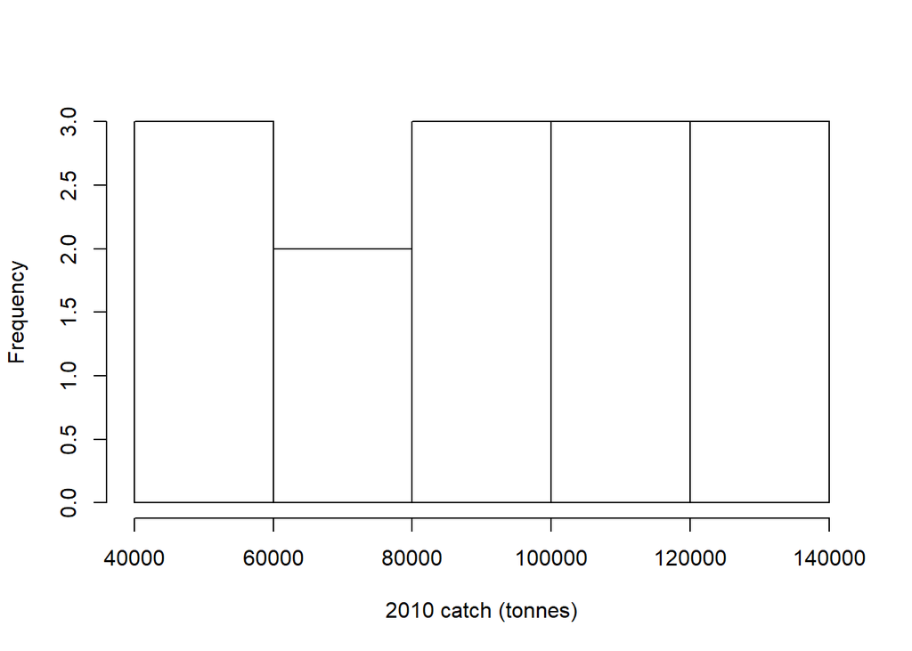

```r
hist(catch2,main="",xlab="2010 catch (tonnes)")
```

3. A paired two-sample t-test would be best for this scenario, because each year’s catch is by village.

```r
t.test(catch1,catch2,paired=T)
```

```
##
##  Paired t-test
##
## data:  catch1 and catch2
## t = 6.3808, df = 13, p-value = 2.415e-05
## alternative hypothesis: true difference in means is not equal to 0
## 95 percent confidence interval:
##   8882.005 17975.138
## sample estimates:
## mean of the differences
##                13428.57
```

```r
qt(0.95,13)
```

```
## [1] 1.770933
```

$t_{obs}=6.38$ $t_{crit}=1.77$

6. Both $t_{obs}>t_{crit}$ and p<0.05, indicating that there is evidence to reject the null hypothesis that the mean catch from 2009 and 2010 are equal.

# Scenario 2

1. $H_0:\mu=15$  
   $H_A:\mu>15$

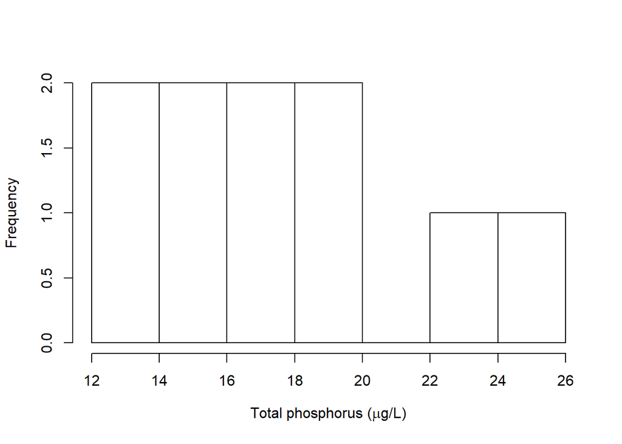

```r
P=c(18.4,12.9,15.3,18.3,15.6,23.3,16.5,12.3,24.6,16.2)
hist(P,main="",xlab=expression(paste("Total phosphorus (",mu,"g/L)")))
```

3. A one-sample t-test would be best for this scenario.

```r
t.test(P,mu=15)
```

```
##
##  One Sample t-test
##
## data:  P
## t = 1.8462, df = 9, p-value = 0.09794
## alternative hypothesis: true mean is not equal to 15
## 95 percent confidence interval:
##  14.47278 20.20722
## sample estimates:
## mean of x
##     17.34
```

```r
0.09794/2
```

```
## [1] 0.04897
```

```r
qt(0.95,9)
```

```
## [1] 1.833113
```

$t_{obs}=1.8462$ $t_{crit}=1.8331$  
f)  
Both $t_{obs}>t_{crit}$ and p=0.048 which indicates that there is evidence to reject the null hypothesis that the mean phosphorus levels are equal to 15 $\mu$g/L.Therefores there is evidence to support the alternative hypothesis that the mean phosphorus levels are greater than 15 $\mu$g/L.

# Scenario 3

1. $H_0:\mu_a=\mu_b$  
   $H_A:\mu_a\neq\mu_b$

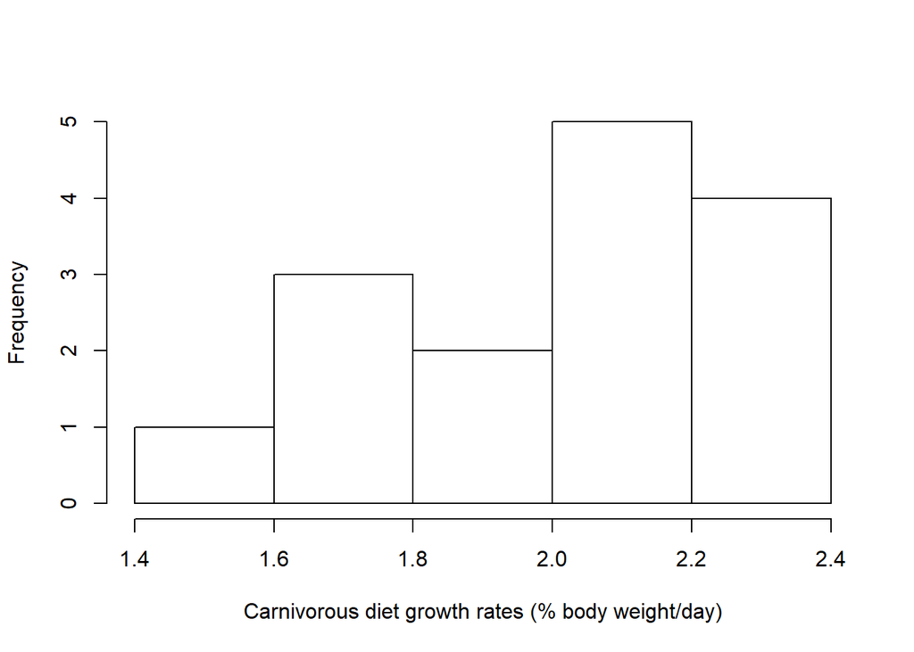

```r
meat=c(2.3,1.8,1.9,1.8,2.1,2.3,2.0,2.2,2.2,1.5,1.8,2.1,2.3,2.2,2.3)
veg=c(1.6,1.1,0.7,1.0,1.0,0.9,1.2,0.8,0.9,0.6,0.7,0.6,0.8,0.8,1.1)
hist(meat,main="",xlab="Carnivorous diet growth rates (% body weight/day)")
```

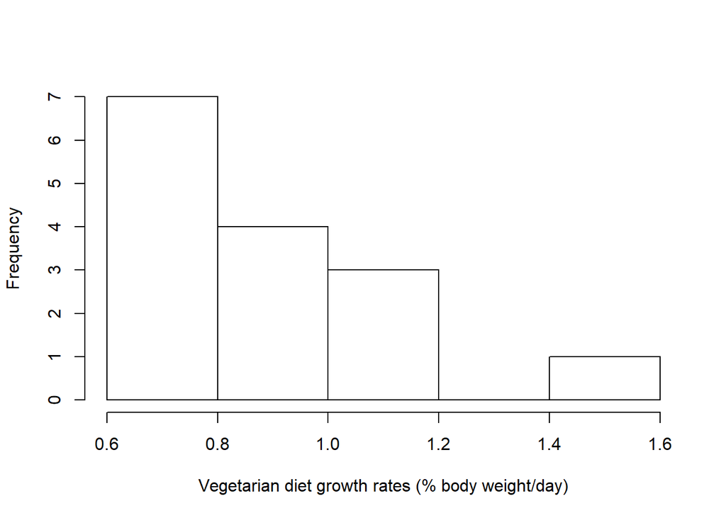

```r
hist(veg, main = "",xlab="Vegetarian diet growth rates (% body weight/day)")
```

3. An independent two sample t-test would be best for this scenario.

```r
t.test(meat,veg)
```

```
##
##  Welch Two Sample t-test
##
## data:  meat and veg
## t = 12.237, df = 27.862, p-value = 1.008e-12
## alternative hypothesis: true difference in means is not equal to 0
## 95 percent confidence interval:
##  0.9435752 1.3230915
## sample estimates:
## mean of x mean of y
##  2.053333  0.920000
```

```r
qt(0.95,27)
```

```
## [1] 1.703288
```

$t_{obs}=12.237$ $t_{crit}=1.7032$  
f)  
Both $t_{obs}>t_{crit}$ and p<0.05, indicating that there is evidence to reject the null hypothesis that the mean growth rates are the same between carnivorous and vegetarian supplements.

# Scenario 4

1. $H_0:$PCB poisoning is independent of trophic level  
   $H_A:$PCB poisoning is dependent on trophic level

```r
level1=c(133,100,17)
top=c(4,61,35)
poison=data.frame(level1,top)
poison
```

```
##   level1 top
## 1    133   4
## 2    100  61
## 3     17  35
```

3. A Chi-squared test would be best for this scenario.

```r
chisq.test(poison)
```

```
##
##  Pearson's Chi-squared test
##
## data:  poison
## X-squared = 89.253, df = 2, p-value < 2.2e-16
```

```r
qchisq(0.95,2)
```

```
## [1] 5.991465
```

$X^2_{obs}=89.253$ $X^2_{crit}=5.9914$  
f)  
Both $X^2_{obs}>X^2_{crit}$ and p<0.05, indicating that there is evidence to reject the null hypothesis that PCB poisoning is independent of trophic level.